# Project memo

ADA

```r
library(tidyverse)
library(broom)
library(skimr)
```

## Data Clean Up Steps for Overall Data

### Cleaning both data sets

In this step, we cleaned the demographic data set to remove the percentage sign from each usage rate so that the numbers can be more easily used, and we turned each demographic group into variables called “race” and “gender”, opposed to each group having its own variable.

```r
setwd("/cloud/project/proposal")
library(readr)
social <- read_csv("../data/which_social_media_platforms_are_most_popular_data_2024-11-13.csv", skip = 2, n_max = 17)
demographic <- read_csv("../data/social_media_usage_among_demographic_groups - Sheet1 (1).csv", skip = 1)
demographic_clean <- demographic %>%
  mutate(Group = as.character(Group)) %>%
  mutate(across(
    .cols = where(~ any(grepl("%", .x, fixed = TRUE), na.rm = TRUE)),
    .fns  = ~ as.numeric(gsub("%", "", .x))
  )) %>%
  mutate(
    gender = case_when(
      Group %in% c("Men", "Women") ~ Group,
      TRUE ~ NA_character_
    ),
    race = case_when(
      Group %in% c("White", "Black", "Hispanic", "Asian") ~ Group,
      TRUE ~ NA_character_
    )
  ) %>%
  pivot_longer(
    cols = -c(Group, gender, race),
    names_to  = "platform",
    values_to = "percent"
  ) %>%
  filter(!is.na(platform))
```

In this step, we cleaned the social data set to remove the percentage sign from each usage rate so that the numbers can be more easily used, brought each social media platform into a variable called “platform”, and adjusted the year variable to be in month/day/year format.

```r
social_clean <- social %>%
  mutate(across(where(is.character),
                ~ as.numeric(ifelse(is.na(.), NA, gsub("%", "", .))))) %>%
  rename(date = Year) %>%
  pivot_longer(
    cols = -date,
    names_to = "platform",
    values_to = "percent"
  ) %>%
  mutate(year = lubridate::year(lubridate::mdy(date)))
```

## Plots

Why These Visualizations Were Chosen: To explore how social media usage varies across different demographic groups and over time, we selected grouped bar charts and small-multiple panel layouts. These visualizations make it easy to compare platforms side by side while still highlighting differences between races, genders, and years. Grouped bar charts allow for direct numerical comparison across categories, and the small multiple format keeps each platform visually consistent while reducing clutter. Together, these choices provide a clear structure for identifying trends, disparities, and patterns in social media behavior across U.S. adults.

### Plot 1: Platform Usage by Race

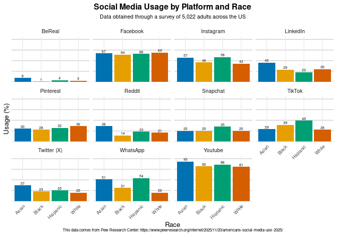

```r
cb_palette <- c(
  "Asian" = "#0072B2",
  "Black" = "#E69F00",
  "Hispanic" = "#009E73",
  "White" = "#D55E00",
  "Other" = "#CC79A7"
)

ggplot(demographic_clean %>% filter(!is.na(race)),
       aes(x = race, y = percent, fill = race)) +
  geom_bar(stat = "identity", position = position_dodge(width = 0.9)) +
  geom_text(
    aes(label = percent),
    position = position_dodge(width = 0.9),
    vjust = -0.3,
    size = 1.8
  ) +
  labs(
    title = "Social Media Usage by Platform and Race",
    subtitle = "Data obtained through a survey of 5,022 adults across the US",
    caption = paste("This data comes from Pew Research Center: https://www.pewresearch.org/internet/2025/11/20/americans-social-media-use-2025/"),
    x = "Race",
    y = "Usage (%)"
  ) +
  scale_fill_manual(values = cb_palette) +
  facet_wrap(~ platform, nrow = 3) +
  scale_y_continuous(
    limits = c(0, 100),
    expand = expansion(mult = c(0, 0.07))
  ) +
  theme_minimal(base_size = 10) +
  theme(
    axis.text.y = element_blank(),
    axis.ticks.y = element_blank(),
    panel.grid.major.y = element_line(color = "gray80"),
    panel.grid.minor = element_blank(),
    axis.text.x = element_text(size = 7, angle = 45, hjust = 1),
    plot.title = element_text(face = "bold", size = 12, hjust = 0.5),
    plot.subtitle = element_text(size = 8, hjust = 0.5, margin = margin(b = 8)),
    plot.caption = element_text(size = 6, hjust = 0.5, margin = margin(b = 8)),
    legend.position = "none"
  )
```

```r
ggsave("platform-by-race.png", width = 4, height = 4)
```

### Plot 2: Platform Usage by Gender

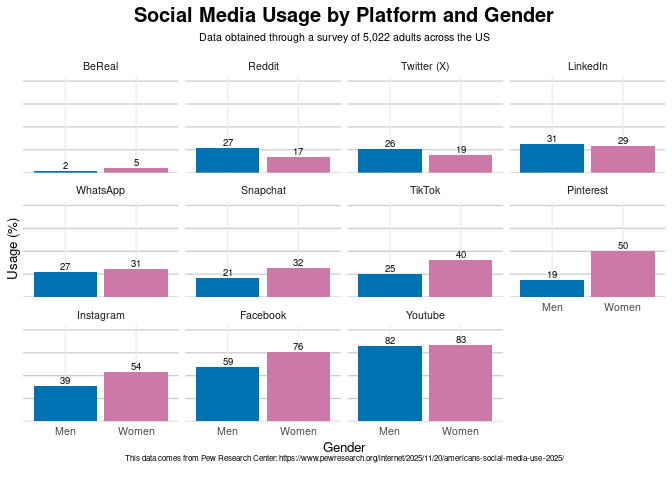

```r
female_usage <- demographic_clean %>%
  filter(gender == "Women") %>%
  select(platform, female_percent = percent)

demographic_sorted <- demographic_clean %>%
  left_join(female_usage, by = "platform") %>%
  mutate(platform = reorder(platform, female_percent))

ggplot(demographic_sorted %>% filter(!is.na(gender)),
       aes(x = gender, y = percent, fill = gender)) +
  geom_bar(stat = "identity", position = position_dodge(width = 0.9)) +
  geom_text(
    aes(label = percent),
    position = position_dodge(width = 0.9),
    vjust = -0.3,
    size = 2.5
  ) +
  scale_fill_manual(values = c("Men" = "#0072B2", "Women" = "#CC79A7")) +
  scale_y_continuous(
    breaks = c(0, 25, 50, 75, 100),
    limits = c(0, 100),
    expand = expansion(mult = c(0, 0.05))
  ) +
  labs(
    title = "Social Media Usage by Platform and Gender",
    subtitle = "Data obtained through a survey of 5,022 adults across the US",
    caption = paste("This data comes from Pew Research Center: https://www.pewresearch.org/internet/2025/11/20/americans-social-media-use-2025/"),
    x = "Gender",
    y = "Usage (%)"
  ) +
  facet_wrap(~ platform, nrow = 3) +
  theme_minimal(base_size = 10) +
  theme(
    axis.text.y = element_blank(),
    axis.ticks.y = element_blank(),
    panel.border = element_blank(),
    panel.grid.major.y = element_line(color = "gray80"),
    panel.grid.minor = element_blank(),
    axis.text.x = element_text(size = 8),
    plot.title = element_text(face = "bold", size = 15, hjust = 0.5),
    plot.subtitle = element_text(size = 8, hjust = 0.5, margin = margin(b = 8)),
    plot.caption = element_text(size = 6, hjust = 0.5, margin = margin(b = 8)),
    legend.position = "none"
  )
```

```r
ggsave("platform-by-gender-facet.png", width = 4, height = 4)
```

From the gender graph, women consistently use visually oriented or communication focused platforms more (e.g., Pinterest, Instagram, Snapchat), while men show higher usage on platforms that emphasize information or discussion, such as Reddit and Twitter (X). This pattern reflects differences in how men and women engage with online spaces and the types of content they prefer.

### Plot 3: Platform Usage by Year

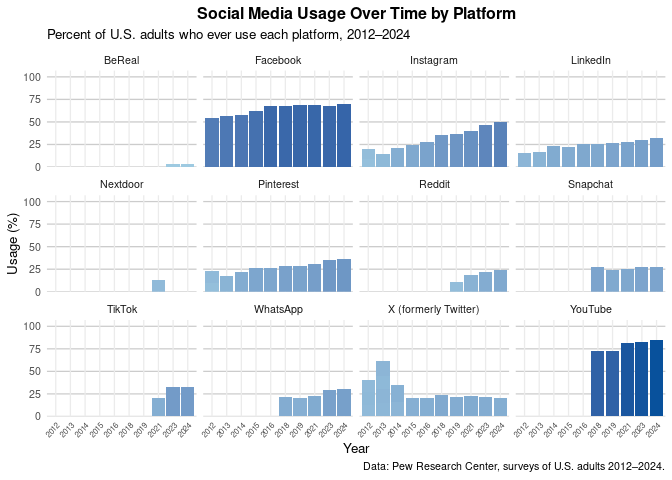

```r
platform_order <- c(
  "YouTube", "Facebook", "Instagram", "Pinterest", "TikTok",
  "LinkedIn", "WhatsApp", "Snapchat",
  "X (formerly Twitter)", "Reddit", "BeReal", "Nextdoor"
)

social_clean <- social %>%
  mutate(across(!Year,
                ~ as.numeric(ifelse(is.na(.), NA, gsub("%", "", .))))) %>%
  rename(date = Year) %>%
  pivot_longer(
    cols = -date,
    names_to  = "platform",
    values_to = "percent"
  ) %>%
  mutate(year = lubridate::year(lubridate::mdy(date)))

ggplot(social_clean, aes(x = factor(year), y = percent, fill = percent)) +
  geom_bar(stat = "identity") +
  facet_wrap(~ platform, nrow = 3) +
  scale_y_continuous(
    limits = c(0, 100),
    expand = expansion(mult = c(0, 0.07))
  ) +
  labs(
    title = "Social Media Usage Over Time by Platform",
    subtitle = "Percent of U.S. adults who ever use each platform, 2012–2024",
    x = "Year",
    y = "Usage (%)",
    caption = "Data: Pew Research Center, surveys of U.S. adults 2012–2024."
  ) +
  scale_fill_gradient(
    low  = "#9ecae1",
    high = "#08519c"
  ) +
  theme_minimal(base_size = 10) +
  theme(
    legend.position = "none",
    axis.text.x = element_text(size = 6, angle = 45, hjust = 1),
    panel.grid.minor = element_blank(),
    panel.grid.major.y = element_line(color = "gray80"),
    plot.title = element_text(face = "bold", size = 12, hjust = 0.5)
  )
```

```r
ggsave("platform-by-year-barchart.png", width = 6, height = 4)
```

Overall, the combined results across race, gender, and time show that social media usage is not uniform. Different groups use different platforms for different purposes, and those preferences shift as new platforms emerge.